# Univariate Graphing Assignment

2015-10-02

### Purpose of Study:

The present study will examine young adults from the The National Longitudinal Study of Adolescent to Adult Health (AddHealth). The goals of the analysis will include 1) establishing the relationship between being in an abusive relationship and individual’s happiness in that abusive relationship; 2) determining whether or not the different forms of abuse would make different impacts to the well-being state of individuals in that abusive relationship; 3) determine how the association/relationship between being in an abusive relationship and individual’s well-being in that abusive relationship may shape differently taking in consideration of ethnicity, age, and sexual orientation.

### Variables:

Variables from AddHealth that will be used include: H4RD2Y (The total amount of time that the individual were involved in a romantic or sexual relationship with their partner), H4RD5 (The amount of nights on an average week when you and your partner spent the night together), H4RD7B (Satisfaction level with the way individuals handle their problems and disagreements), H4RD9 (The level of happiness of individuals in the relationship), H4RD18 (The frequency of physical abuse threats and attempts), H4RD20 (The frequency of physical injures), H4RD21 (The frequency of non-consensual sexual activities“). ￼

### Data Management

First, the data is placed on the search path using the `PDS` package. The variables of interest are selected and stored in the data frame `NDF` using the `select` function from the `dplyr` package. Then, those variables of interest are renamed and given more reasonable names instead of the original unique identifiers from the codebook.

```r
library(PDS)
NDF <- addhealth_public4 %>%
  rename(TimeSpent = h4rd2y, NightsSpent = h4rd5, SatisfactionWConflict = h4rd7b, HappinessLevel = h4rd9, PhysicalAbuseAttempts = h4rd18, PhysicalInjure = h4rd20, SexualAssaults = h4rd21) %>%
  select(TimeSpent, NightsSpent, SatisfactionWConflict, HappinessLevel, PhysicalAbuseAttempts, PhysicalInjure, SexualAssaults)
summary(NDF)
```

```
   TimeSpent       NightsSpent    SatisfactionWConflict HappinessLevel
 Min.   : 0.000   Min.   : 0.00   Min.   : 1.000        Min.   :1.000
 1st Qu.: 1.000   1st Qu.: 5.00   1st Qu.: 1.000        1st Qu.:1.000
 Median : 4.000   Median :97.00   Median : 2.000        Median :1.000
 Mean   : 6.753   Mean   :65.52   Mean   : 2.643        Mean   :2.416
 3rd Qu.: 8.000   3rd Qu.:97.00   3rd Qu.: 3.000        3rd Qu.:2.000
 Max.   :98.000   Max.   :98.00   Max.   :98.000        Max.   :8.000
 NA's   :1536     NA's   :1536    NA's   :1536          NA's   :1536
 PhysicalAbuseAttempts PhysicalInjure  SexualAssaults
 Min.   : 0.000        Min.   : 0.00   Min.   : 0.0000
 1st Qu.: 0.000        1st Qu.:97.00   1st Qu.: 0.0000
 Median : 0.000        Median :97.00   Median : 0.0000
 Mean   : 1.401        Mean   :84.38   Mean   : 0.7701
 3rd Qu.: 0.000        3rd Qu.:97.00   3rd Qu.: 0.0000
 Max.   :98.000        Max.   :98.00   Max.   :98.0000
 NA's   :1536          NA's   :1536    NA's   :1536
```

### Labeling Variables

In the next section of code, responses to the questions are labeled and levels of factors are given informative labels. The order of the levels is also rearranged for the variables `TimeSpent`, `SatisfactionWConflict`, `HappinessLevel`, `PhysicalAbuseAttempts`, `PhysicalInjure`, and `SexualAssaults`, the number of responses is pulled. Then, the factors are given readable names instead of being named with numbers.

The first variables examined are the variables related to the level of satisfactions level with the way individuals handle their problems and disagreements.

```r
xtabs(~SatisfactionWConflict, data = NDF)
```

```
SatisfactionWConflict
   1    2    3    4    5   96   98
1670 1743  711  587  233   11   13
```

```r
NDF$SatisfactionWConflict[NDF$SatisfactionWConflict==96 | NDF$SatisfactionWConflict==98] <- NA
NDF$SatisfactionWConflict <- factor(NDF$SatisfactionWConflict, labels = c("strongly agree", "agree", "neither agree nor disagree", "disagree","strongly disagree"))[, drop = TRUE]
xtabs(~SatisfactionWConflict, data = NDF)
```

```
SatisfactionWConflict
            strongly agree                      agree
                      1670                       1743
neither agree nor disagree                   disagree
                       711                        587
         strongly disagree
                       233
```

The second variables examined are the variables related to the level of happiness of indivduals with their romantic relationship.

```r
xtabs(~HappinessLevel, data = NDF)
```

```
HappinessLevel
   1    2    3    6    7    8
2807  979  258   11  906    7
```

```r
NDF$HappinessLevel[NDF$HappinessLevel>=6] <- NA
NDF$HappinessLevel <- factor(NDF$HappinessLevel, labels = c("very happy", "fairly happy", "not too happy"))[, drop = TRUE]
xtabs(~HappinessLevel, data = NDF)
```

```
HappinessLevel
   very happy  fairly happy not too happy
         2807           979           258
```

The third variables examined are the variables related to the physical abuse threats and attempts toward the other partner in the romantic relationship.

```r
xtabs(~PhysicalAbuseAttempts, data = NDF)
```

```
PhysicalAbuseAttempts
   0    1    2    3    4    5    6    7   96   98
3880  294  306  186  148   48   25   37   28   16
```

```r
NDF$PhysicalAbuseAttempts[NDF$PhysicalAbuseAttempts>=9] <- NA
NDF$PhysicalAbuseAttempts <- factor(NDF$PhysicalAbuseAttempts, labels = c("never", "this has not happened in the past year, but it did happen before then ", "once in the last year of the relationship","twice in the last year of the relationship", "3 to 5 times in the last year of the relationship","6 to 10 times in the last year of the relationship", "11 to 20 times in the last year of the relationship", "more than 20 times in the last year of the relationship"))[, drop = TRUE]
xtabs(~PhysicalAbuseAttempts, data = NDF)
```

```
PhysicalAbuseAttempts
                                                                 never
                                                                  3880
this has not happened in the past year, but it did happen before then
                                                                   294
                             once in the last year of the relationship
                                                                   306
                            twice in the last year of the relationship
                                                                   186
                     3 to 5 times in the last year of the relationship
                                                                   148
                    6 to 10 times in the last year of the relationship
                                                                    48
                   11 to 20 times in the last year of the relationship
                                                                    25
               more than 20 times in the last year of the relationship
                                                                    37
```

The fourth variables examined are the variables related to the individuals’ physical abuse injure frequency in the romantic relationship.

```r
xtabs(~PhysicalInjure, data = NDF)
```

```
PhysicalInjure
   0    1    2    3    4    5    6    7   96   97   98
 395   74   86   32   35   17    2   12   17 4289    9
```

```r
NDF$PhysicalInjure[NDF$PhysicalInjure>=9] <- NA
NDF$PhysicalInjure <- factor(NDF$PhysicalInjure, labels = c("never", "this has not happened in the past year, but it did happen before then ", "once in the last year of the relationship","twice in the last year of the relationship", "3 to 5 times in the last year of the relationship","6 to 10 times in the last year of the relationship", "11 to 20 times in the last year of the relationship", "more than 20 times in the last year of the relationship"))[, drop = TRUE]
xtabs(~PhysicalInjure, data = NDF)
```

```
PhysicalInjure
                                                                 never
                                                                   395
this has not happened in the past year, but it did happen before then
                                                                    74
                             once in the last year of the relationship
                                                                    86
                            twice in the last year of the relationship
                                                                    32
                     3 to 5 times in the last year of the relationship
                                                                    35
                    6 to 10 times in the last year of the relationship
                                                                    17
                   11 to 20 times in the last year of the relationship
                                                                     2
               more than 20 times in the last year of the relationship
                                                                    12
```

The fifth variables examined are the variables related to the non-consensual sexual activities that the individuals were forced to engage in, in the domestic relationship.

```r
xtabs(~SexualAssaults, data = NDF)
```

```
SexualAssaults
   0    1    2    3    4    5    6    7   96   98
4622   58   88   70   56   21   10   13   19   11
```

```r
NDF$SexualAssaults[NDF$SexualAssaults>=9] <- NA
NDF$SexualAssaults <- factor(NDF$SexualAssaults, labels = c("never", "this has not happened in the past year, but it did happen before then ", "once in the last year of the relationship","twice in the last year of the relationship", "3 to 5 times in the last year of the relationship","6 to 10 times in the last year of the relationship", "11 to 20 times in the last year of the relationship", "more than 20 times in the last year of the relationship"))[, drop = TRUE]
xtabs(~SexualAssaults, data = NDF)
```

```
SexualAssaults
                                                                 never
                                                                  4622
this has not happened in the past year, but it did happen before then
                                                                    58
                             once in the last year of the relationship
                                                                    88
                            twice in the last year of the relationship
                                                                    70
                     3 to 5 times in the last year of the relationship
                                                                    56
                    6 to 10 times in the last year of the relationship
                                                                    21
                   11 to 20 times in the last year of the relationship
                                                                    10
               more than 20 times in the last year of the relationship
                                                                    13
```

The sixth variables examined are the variables related to the amount of time spent of the individual were involved in a romantic or sexual relationship with their partner.

```r
xtabs(~TimeSpent, data = NDF)
```

```
TimeSpent
  0   1   2   3   4   5   6   7   8   9  10  11  12  13  14  15  16  17
946 537 438 406 343 341 305 322 296 224 255 138 127  78  43  31  11   8
 18  19  96  98
  1   1  57  60
```

```r
NDF$TimeSpent[NDF$TimeSpent == 96] <- NA
NDF$TimeSpent[NDF$TimeSpent == 98] <- NA
NDF$TimeSpent <- factor(NDF$TimeSpent, labels = c(0, 1, 2, 3, 4, 5, 6, 7, 8, 9, 10, 11, 12, 13, 14, 15, 16, 17, 18, 19))[, drop = TRUE]
xtabs(~TimeSpent, data = NDF)
```

```
TimeSpent
  0   1   2   3   4   5   6   7   8   9  10  11  12  13  14  15  16  17
946 537 438 406 343 341 305 322 296 224 255 138 127  78  43  31  11   8
 18  19
  1   1
```

```r
xtabs(~NightsSpent, data = NDF)
```

```
NightsSpent
   0    1    2    3    4    5    6    7   95   96   97   98
 327  311  261  201  128  128   63  241   12   14 3273    9
```

```r
NDF$NightsSpent[NDF$NightsSpent>=8] <- NA
NDF$NightsSpent <- factor(NDF$NightsSpent, labels = c(0, 1, 2, 3, 4, 5, 6, 7))[, drop = TRUE]
xtabs(~NightsSpent, data = NDF)
```

```
NightsSpent
  0   1   2   3   4   5   6   7
327 311 261 201 128 128  63 241
```

### Variables

The barplots are all created with the package `ggplot2`. The barplots start with the defaults for the `geom_bar` and add more detail to the plot with each graph.

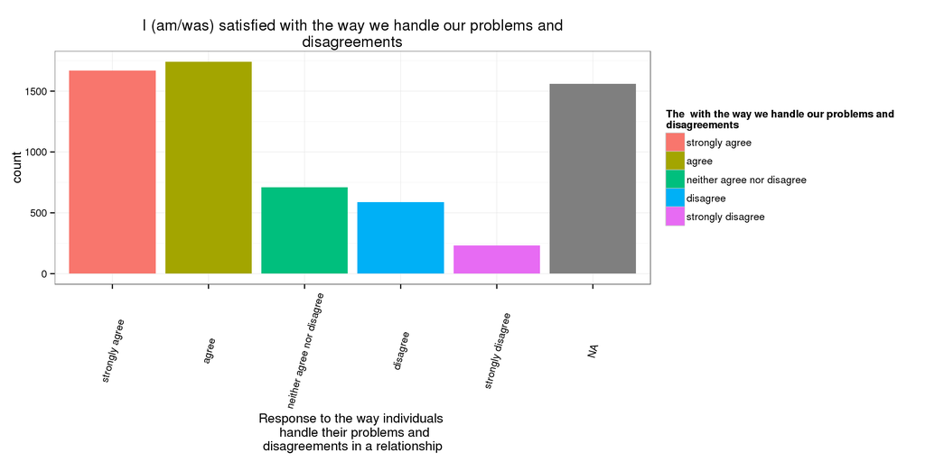

```r
library(ggplot2)

ggplot(data = NDF, aes(x = SatisfactionWConflict, fill = SatisfactionWConflict)) +
  geom_bar() +
  labs(title = "I (am/was) satisfied with the way we handle our problems and
disagreements", x = "Response to the way individuals \n handle their problems and
disagreements in a relationship") +
  theme_bw() +
  theme(axis.text.x  = element_text(angle = 75, vjust = 0.5)) +
  guides(fill = guide_legend(title = "The  with the way we handle our problems and
disagreements"))
```

The second graph showed the variables related to the level of happiness of indivduals with their romantic relationship including very happy, fairly happy, and not too happy. And the graph is skewed right distribution.

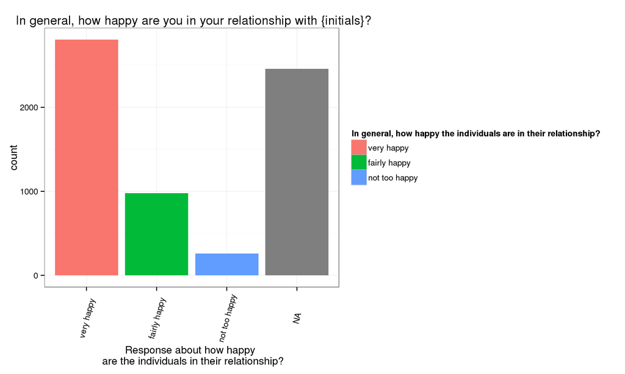

```r
ggplot(data = NDF, aes(x = HappinessLevel, fill = HappinessLevel)) +
  geom_bar() +
  labs(title = " In general, how happy are you in your relationship with {initials}?", x = "Response about how happy \n are the individuals in their relationship?") +
  theme_bw() +
  theme(axis.text.x  = element_text(angle = 75, vjust = 0.5)) +
  guides(fill = guide_legend(title = "In general, how happy the individuals are in their relationship?"))
```

From the third graph to the fifth graph, there are 7 responses that the individuals can choose range from “this has not happened in the past year but it did happen before” to “more than 20 times in the past year in the relationship”. The third graph portrays the variables related to the physical abuse threats and attempts toward the other partner in the romantic relationship. I omitted the NA population so the graph can be easily analyzed and representable to identify the behavior. The graph is very similar to skewed right distribution.

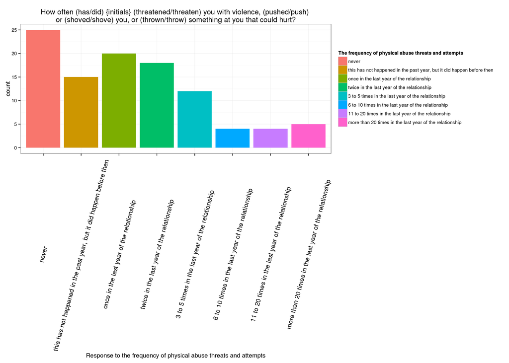

```r
ggplot(data = na.omit(NDF), aes(x = PhysicalAbuseAttempts, fill = PhysicalAbuseAttempts)) +
  geom_bar() +
  labs(title = "How often (has/did) {initials} (threatened/threaten) you with violence, (pushed/push) \n or (shoved/shove) you, or (thrown/throw) something at you that could hurt? ", x = "Response to the frequency of physical abuse threats and attempts") +
  theme_bw() +
  theme(axis.text.x  = element_text(angle = 75, vjust = 0.5, size = 13)) +
  guides(fill = guide_legend(title = "The frequency of physical abuse threats and attempts", legend.key.size = 12))
```

The fourth graph portrays the variables related to the individuals’ physical abuse injure frequency in the romantic relationship. There was an overwhelming majority that legitimately skip or ignore the question which it is hard to make conjecture on the reason why they did it. Therefore, I omitted that population so the graph can be easily analyzed and representable to identify the behavior. The graph is very similar to skewed right distribution. The majority responded never but there was still considerable populations that experienced physical injures in their relationships.

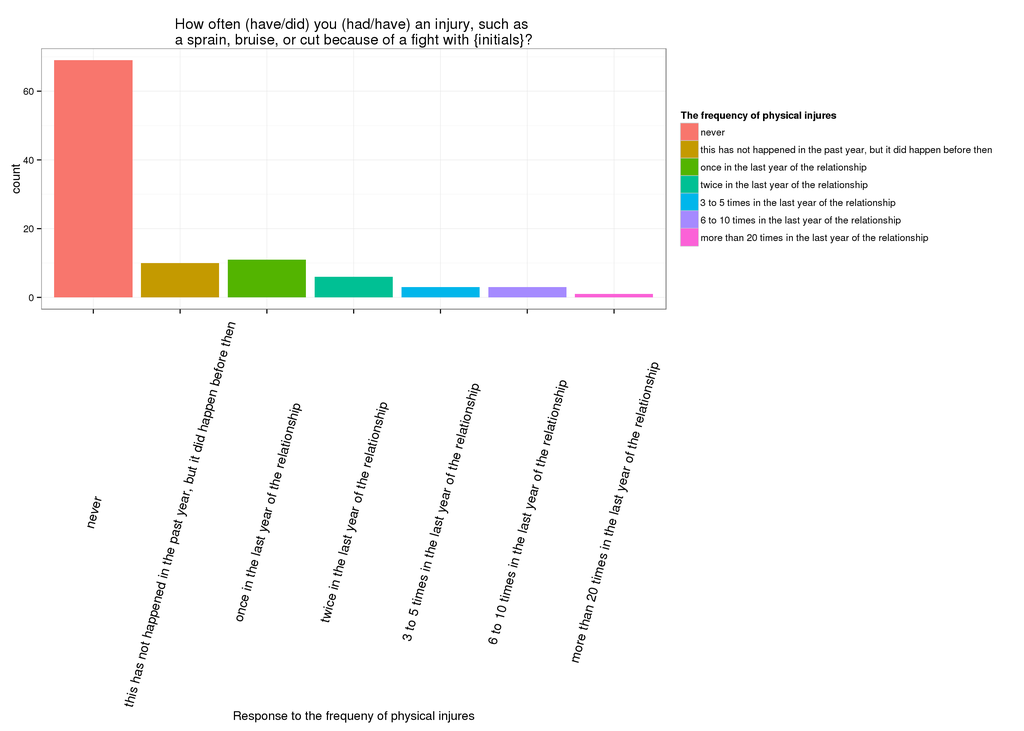

```r
ggplot(data = na.omit(NDF), aes(x = PhysicalInjure, fill = PhysicalInjure)) +
  geom_bar() +
  labs(title = "How often (have/did) you (had/have) an injury, such as \n a sprain, bruise, or cut because of a fight with {initials}? ", x = "Response to the frequeny of physical injures") +
  theme_bw() +
  theme(axis.text.x  = element_text(angle = 75, vjust = 0.5, size = 13)) +
  guides(fill = guide_legend(title = "The frequency of physical injures"))
```

The fifth graph portrays the variables related to the non-consensual sexual activities that the individuals were forced to engage in, in the domestic relationship. I omitted the NA population so the graph can be easily analyzed and representable to identify the behavior. The graph is very similar to skewed right distribution. There was a more significant majority responded never to the non-consensual sexual activities that they engage in compare to the previous question of the frequency of physical injures.

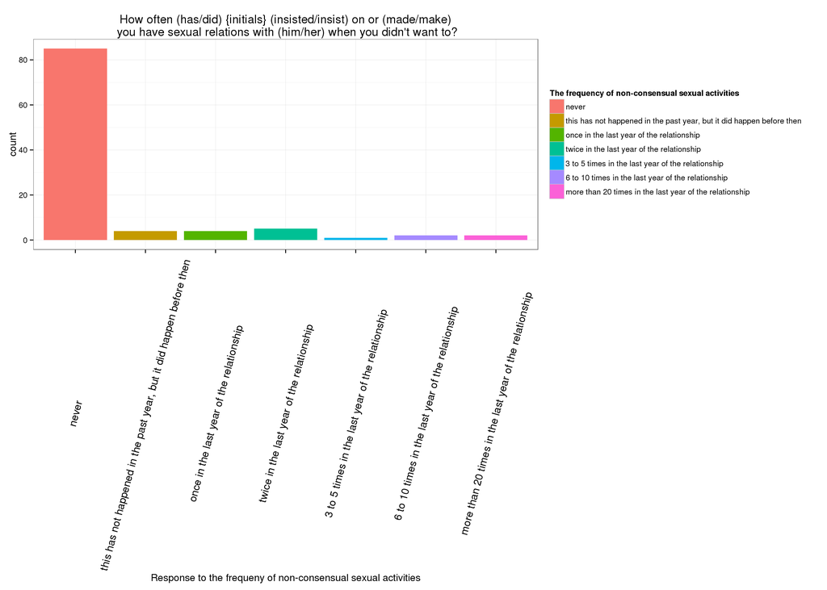

```r
ggplot(data = na.omit(NDF), aes(x = SexualAssaults, fill = SexualAssaults)) +
  geom_bar() +
  labs(title = " How often (has/did) {initials} (insisted/insist) on or (made/make) \n you have sexual relations with (him/her) when you didn't want to?", x = "Response to the frequeny of non-consensual sexual activities") +
  theme_bw() +
  theme(axis.text.x  = element_text(angle = 75, vjust = 0.5, size = 13)) +
  guides(fill = guide_legend(title = "The frequency of non-consensual sexual activities"))
```

The sixth graph portrays the variables related to the amount of time that the individual spent together with their significant other in a sexual or romantic relationship. I omitted the NA population so the graph can be easily analyzed and representable to identify the behavior. The mean of the graph is around at 4.576 years and the median is 4 years. The graph distribution is skewed right.

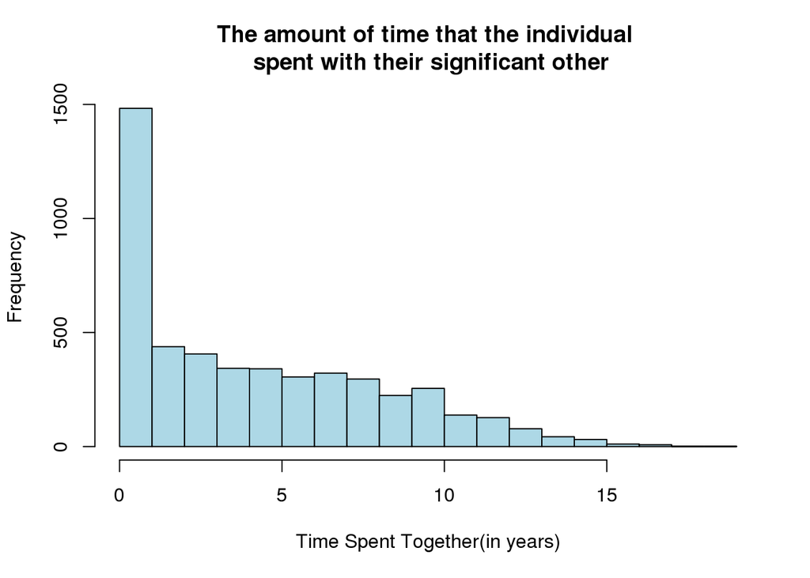

```r
NDF$TimeSpent <- gsub(",", "", NDF$TimeSpent)   # remove comma
NDF$TimeSpent <- as.numeric(NDF$TimeSpent)
hist(NDF$TimeSpent, xlab = "Time Spent Together(in years)", main= "The amount of time that the individual \n spent with their significant other", col= "light blue", breaks=c(0,1,2,3,4,5,6,7,8,9,10,11,12,13,14,15,16,17,18,19))
```

```r
summary(NDF$TimeSpent)
```

```
   Min. 1st Qu.  Median    Mean 3rd Qu.    Max.    NA's
  0.000   1.000   4.000   4.576   7.500  19.000    1653
```

```r
fivenum(NDF$TimeSpent)
```

```
[1]  0.0  1.0  4.0  7.5 19.0
```

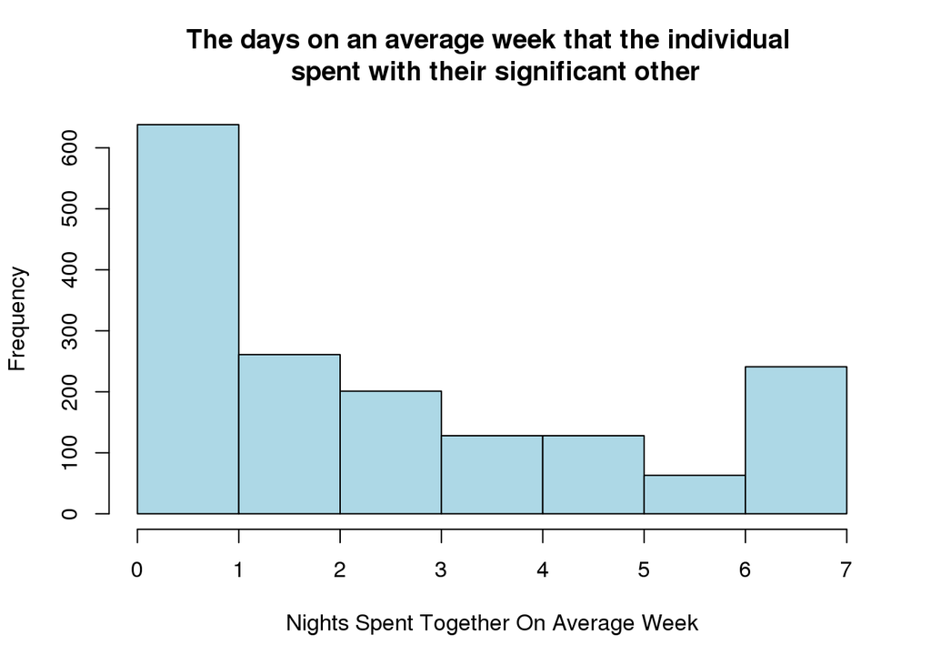

```r
NDF$NightsSpent <- gsub(",", "", NDF$NightsSpent)
NDF$NightsSpent <- as.numeric(NDF$NightsSpent)
hist(NDF$NightsSpent, xlab = "Nights Spent Together On Average Week", main= "The days on an average week that the individual \n spent with their significant other", col= "light blue", breaks=c(0,1,2,3,4,5,6,7))
```

```r
summary(NDF$NightsSpent)
```

```
   Min. 1st Qu.  Median    Mean 3rd Qu.    Max.    NA's
  0.000   1.000   2.000   2.803   5.000   7.000    4844
```

```r
fivenum(NDF$NightsSpent)
```

```
[1] 0 1 2 5 7
```